# Pertemuan 1 - Pemulusan

#### 7.4.2 Plot deret waktu (winter multiplikatif)

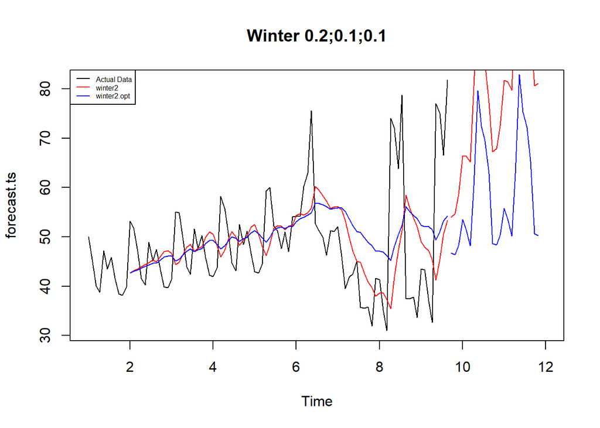

```r
#Plot time series
plot(forecast.ts,main="Winter 0.2;0.1;0.1",type="l",col="black",
     xlim=c(1,12),pch=12)
lines(xhat2,type="l",col="red")
lines(xhat2.opt,type="l",col="blue")
lines(forecast2,type="l",col="red")
lines(forecast2.opt,type="l",col="blue")
legend("topleft",c("Actual Data",expression(paste(winter2)),
                   expression(paste(winter2.opt))),cex=0.5,
       col=c("black","red","blue"),lty=1)
```

#### 7.4.3 Akurasi data ramal

```r
#Akurasi data training
SSE2<-winter2$SSE
MSE2<-winter2$SSE/length(forecast.ts)
RMSE2<-sqrt(MSE2)
akurasi1 <- matrix(c(SSE2,MSE2,RMSE2))
row.names(akurasi1)<- c("SSE2", "MSE2", "RMSE2")
colnames(akurasi1) <- c("Akurasi lamda=0.2")
akurasi1
```

```
##       Akurasi lamda=0.2
## SSE2        12217.96374
## MSE2          127.27046
## RMSE2          11.28142
```

Didapatkan hasil SSE sebesar 12217.96, MSE sebesar 127.27, serta RMSE sebesar 11.28.

```r
#Akurasi data latih, dengan parameter optimum
SSE2.opt<-winter2.opt$SSE
MSE2.opt<-winter2.opt$SSE/length(forecast.ts)
RMSE2.opt<-sqrt(MSE2.opt)
akurasi1.opt <- matrix(c(SSE2.opt,MSE2.opt,RMSE2.opt))
row.names(akurasi1.opt)<- c("SSE2.opt", "MSE2.opt", "RMSE2.opt")
colnames(akurasi1.opt) <- c("Akurasi")
akurasi1.opt
```

```
##               Akurasi
## SSE2.opt  11028.71149
## MSE2.opt    114.88241
## RMSE2.opt    10.71832
```

Didapatkan hasil SSE sebesar 11028.71, MSE sebesar 114.88, serta RMSE sebesar 10.72.

Lalu dibuat sebuah tabel untuk melihat perbandingan antara winter multiplikatif dengan yang menggunakan parameter optimum maupun bukan yang optimum.

```r
akurasi2.forecast = data.frame(Model_Winter = c("Winter 1","winter2 optimal"),
                            Nilai_SSE=c(SSE2,SSE2.opt),
                            Nilai_MSE=c(MSE2,MSE2.opt),Nilai_RMSE=c(RMSE2,RMSE2.opt))
akurasi2.forecast
```

```
##      Model_Winter Nilai_SSE Nilai_MSE Nilai_RMSE
## 1        Winter 1  12217.96  127.2705   11.28142
## 2 winter2 optimal  11028.71  114.8824   10.71832
```

#### 7.4.4 Akurasi Data Uji (Winter Multiplikatif)

```r
#Akurasi Data Testing
forecast2<-data.frame(forecast2)
testing.ts<-data.frame(test.ts)
selisih2<-forecast2-testing.ts
SSEtesting2<-sum(selisih2^2)
MSEtesting2<-SSEtesting2/length(testing.ts)

forecast2.opt<-data.frame(forecast2.opt)
selisih2.opt<-forecast2.opt-testing.ts
SSEtesting2.opt<-sum(selisih2.opt^2)
MSEtesting2.opt<-SSEtesting2.opt/length(testing.ts)

SSEtesting2
```

```
## [1] 36984.97
```

```r
SSEtesting2.opt
```

```
## [1] 9913.769
```

## 8. Keputusan Metode Pumulusan Terbaik

#### 8.1 SMA atau DMA?

Pada langkah metode Single Moving Average (SMA) dan Double Moving Average (DMA) telah diketahui metode pemulusan dengan **Single Moving Average (SMA) lebih baik** dibandingkan dengan DMA. Hal ini diakibatkan nilai MAPE yang diberikan oleh pemulusan dengan SMA lebih kecil dibandingkan dengan DMA.

#### 8.2 SES **atau DES?**

Metode **Double Exponential Smoothing (DES) lebih baik** dibandingkan metode SES dilihat dari MSE yang lebih kecil nilainya. Hal ini sesuai sebab metode pemulusan DES lebih baik digunakan untuk data yang trend (bukan stasioner/konstan).

#### 8.3 Winter Aditif atau Multiplikatif?

Sebelumnya dimanfaatkan nilai frequency=11 dengan parameter yang optimum, sehingga untuk winter aditif diperoleh keakuratan data ramal dengan nilai SSE sebesar **11951.95** dengan nilai SSE data uji sebesar **40287.72**. Sedangkan untuk winter multiplikatif diperoleh keakuratan data ramal dengan nilai SSE sebesar **11028.71** dengan nilai SSE data uji **9913.769**. Karena SSE data latih winter multiplikatif < daripada SSE data latih winter aditif, serta SSE data uji winter multiplikatif juga < daripada SSE data uji winter aditif maka dapat dikatakan **winter multiplikatif lebih baik** dibandingkan metode pemulusan winter aditif.

**8.4 SMA, DES, atau winter multiplikatif?**

```r
#SMA vs DES

#SMA
cat("MAPE data ramal SMA:", MAPE_dt.ramal.sma, "\n")
```

```
## MAPE data ramal SMA: 15.61109
```

```r
cat("MAPE data uji SMA:", MAPE_dt.uji.sma, "\n\n")
```

```
## MAPE data uji SMA: 69.76289
```

```r
#DES
cat("MAPE data ramal DES:", mapedes.forecast2, "\n")
```

```
## MAPE data ramal DES: 13.61711
```

```r
cat("MAAPE data uji DES:", MAPEtestingdes2, "\n")
```

```
## MAAPE data uji DES: 256.1443
```

```r
cat("MAPE data ramal optim DES:", MAPEtestingdesopt , "\n\n")
```

```
## MAPE data ramal optim DES: 118.6527
```

```r
#Diambil yang SMA karena mayoritas akurasi MAPE SMA didapatkan < daripada akurasi MAPE pada DES

#SMA vs winter multiplikatif

#SMA
cat("SSE data ramal SMA:", SSE_dt.ramal.sma, "\n")
```

```
## SSE data ramal SMA: 11171.18
```

```r
cat("SSE data uji SMA:", SSE_dt.uji.sma, "\n\n")
```

```
## SSE data uji SMA: 22848.13
```

```r
#Winter multiplikatif
cat("SSE data ramal optim winter multi:", SSE2.opt, "\n")
```

```
## SSE data ramal optim winter multi: 11028.71
```

```r
cat("SSE data uji optim winter multi:", SSEtesting2.opt, "\n")
```

```
## SSE data uji optim winter multi: 9913.769
```

Oleh karena itu, untuk data tersebut disarankan menggunakan **metode pemulusan winter multiplikatif.**

## 9. Saran

Terkait data yang digunakan terkategorikan sebagai data yang kurang baik, hal ini disebabkan terlihat adanya dua pola yang berbeda. Maka hal ini mengakibatkan sulitnya menentukan pola sebaran data. Secara garis besar pola data deret waktu ada pola horizontal (konstan), pola musiman, pola siklis, ataupun pola trend. Pada analisis kali ini diasumsikan polanya mengikuti pola trend ataupun musiman dengan pengambilan asumsi berdasarkan eksplorasi data memalui plot time series. Sehingga hal ini mengakibatkan diharuskan mencoba satu persatu dari beragam metode pemulusan yang tersedia.